# Modelo de recomendación de hoteles

3 de agosto de 2015

## Antecedentes

- Los clientes no conocen los hoteles
- Hay que promover que vean la opción adecuada
- **Idea:** Recomendar hoteles similares a uno dado
- Sección de hoteles similares
- ¿Cómo se hace actualmente?
  - Mismo destino
  - Mismas estrellas
  - ¿Ordenados por Sort Order?

## Antecedentes

- No está mal, pero:
  - No aprovecha la información disponible
  - Es poco robusto
  - ¿Habrá alguna alternativa?
- Veamos qué hace la competencia…

## Price Travel

Gracias por participar…

## Booking

- Posición: Izquierda, algo abajo
- Populares por destino (al principio)
- Recientemente vistos (después)

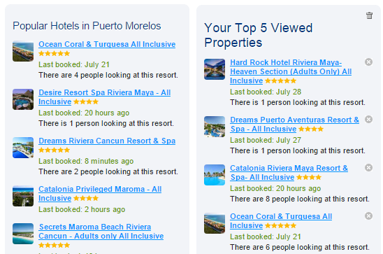

## Despegar

- Posición: Izquierda, abajo
- Hoteles recientemente vistos
- Hoteles cercanos (aunque no se parezcan)
- Populares por destino

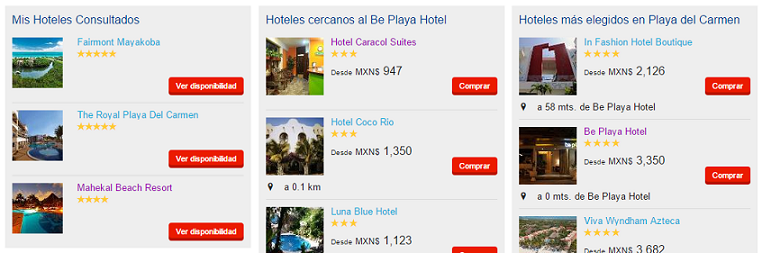

## Trip Advisor

- No es competencia, pero ¿qué podemos aprender?
- Posición: Derecha, abajo
- Método desconocido, pero no es por estrellas

[figure not shown]

## Expedia

- Posición: Centro, hasta abajo
- Hoteles recientemente vistos
- Método desconocido, pero no es por estrellas
  - Me gustó, aunque es algo rígido

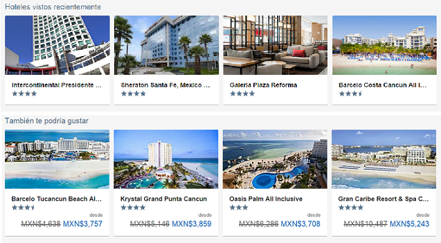

## ¿Qué aprendimos?

- No hay un estándar en la industria
- Salvo tal vez las consultas recientes
  - Ya lo tenemos
- Hay varios criterios, pero
  - No siempre aplican
  - Algunos son los mismos por destino
  - **Casi nadie integra varios criterios**
    - Salvo Expedia y TripAdvisor
- Veamos el caso Best Day con mayor detalle

## Ejemplos

[figure not shown]

[figure not shown]

## Ejemplos

[figure not shown]

[figure not shown]

## Problemas

- Se ignora el precio del hotel
- No se toma en cuenta la filosofía del hotel
- La información geográfica no se aprovecha
- El criterio es estático
- Las recomendaciones no cambian por destino y estrellas

## Wish List

- No mostrar hoteles demasiado caros
- Tomar en cuenta el perfil de los hoteles además de su categoría
- Incorporar información geográfica detallada
- Hacer que el criterio sea dinámico
- Que las recomendaciones lleven a nuevas opciones

## ¿Y si en lugar de esto…

[figure not shown]

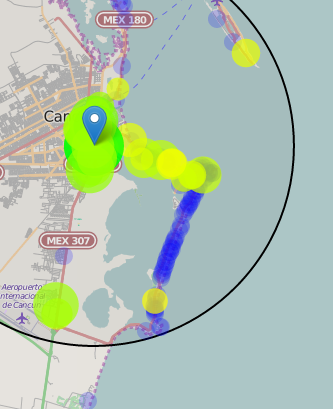

## … recomendáramos esto?

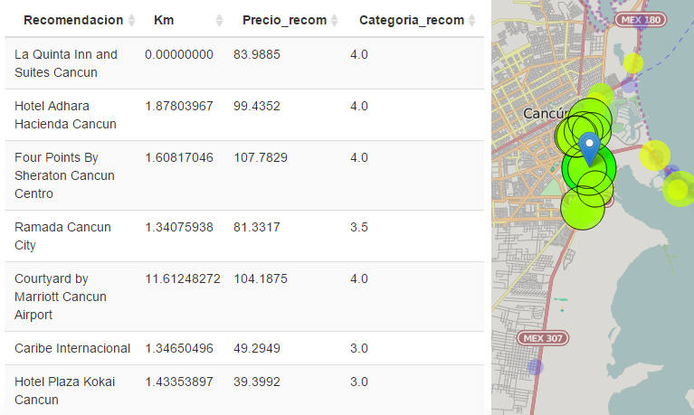

## Plan de ataque

1. Evitar hoteles demasiado caros
2. Diseñar un criterio integral de similitud
   - Categorías de servicios
     - Cantidad de servicios
     - Perfil similar
3. Recomendar hoteles geográficamente cercanos
   - Es mejor que el destino

## Precio

- Poner hoteles demasiado caros no promueve el interés del cliente
- Favorecer precios bajos
- Porcentaje máximo arriba del hotel original
  - En principio, más barato es mejor
  - Siempre y cuando tenga la categoría suficiente
- Hoteles por encima del precio establecido son invisibles

## Caracterización de hoteles

- Mismas estrellas no garantizan similitud
- Usar información de servicios
- Directamente es ruidosa: no toma en cuenta los sustitutos
- **Solución:** Agrupar servicios en categorías equivalentes
- **Método:** Manual + aglomerado jerárquico:

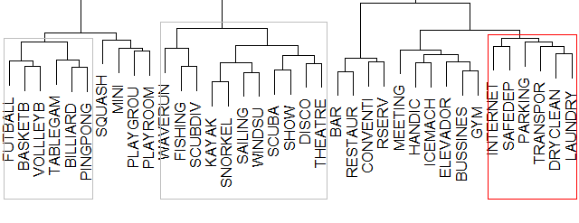

## Similitud

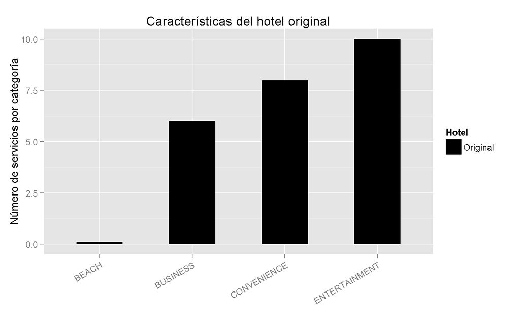

## Similitud (servicios)

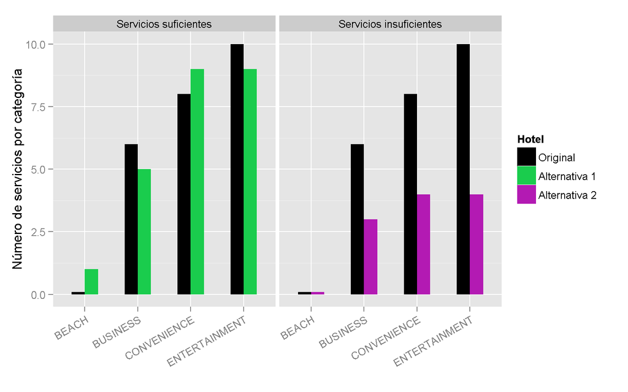

## Similitud (servicios)

- El cliente busca al menos ciertos servicios
- Los servicios faltantes restan similitud
- Los servicios extras no se penalizan

## Similitud (perfil)

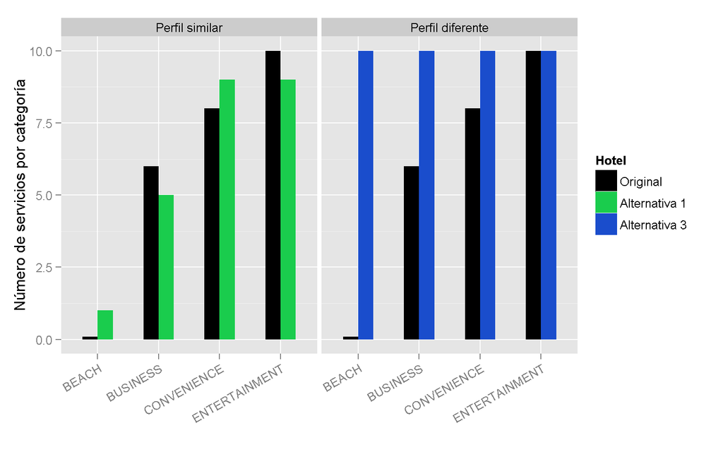

## Similitud (perfil)

- Misma proporción de cada tipo de servicios
- No importa la cantidad en sí
- Puede dar hoteles más sencillos/más lujosos

## Similitud (servicios + perfil)

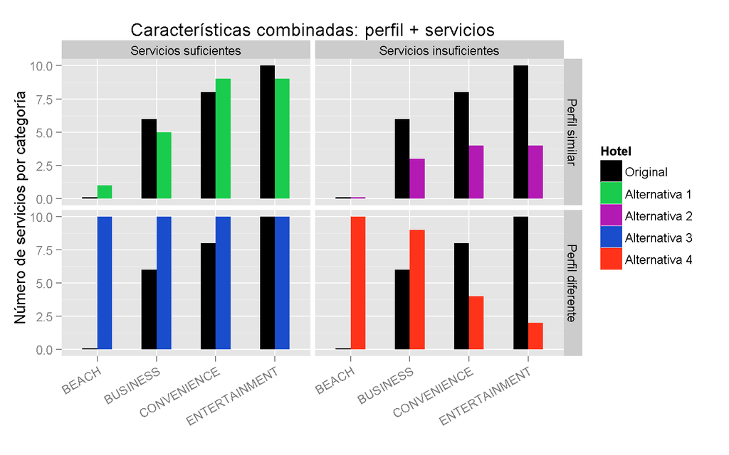

## Similitud (servicios + perfil)

- Medida de similitud de **servicios**: Calidad mínima
- Medida de similitud de **perfil**: Proporciones de servicios
- **Medida de similitud final:**
  - Capturar ambos efectos
  - Promedio entre ambas medidas
  - Ponderación de acuerdo a la variabilidad de cada una (ACP)
- ¿Por qué no diferencia absoluta?
  - Es muy agresiva
  - No es ajustable

## Cercanía

- Lo importante es la distancia
- ¿Qué significa "cerca"?
  - Depende de densidad de hoteles
  - Criterio dinámico
- Evitar enmascaramiento por hoteles distintos

## Densidad baja (de hoteles similares)

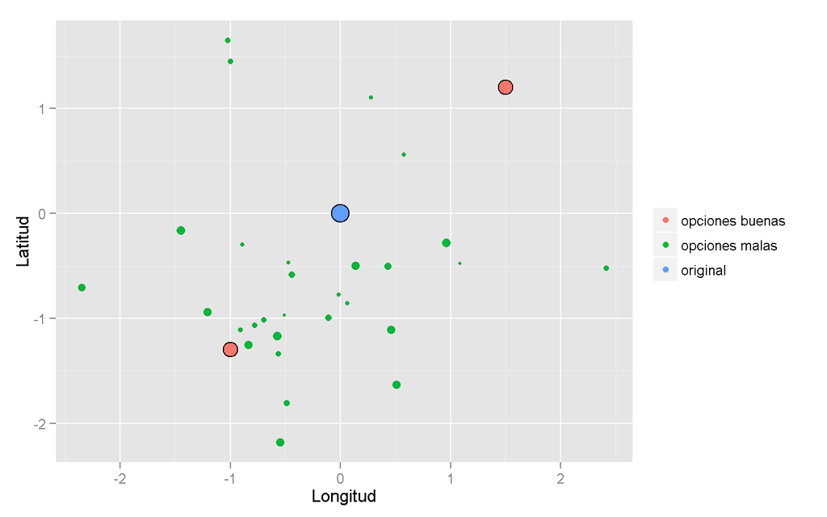

## Densidad alta (de hoteles similares)

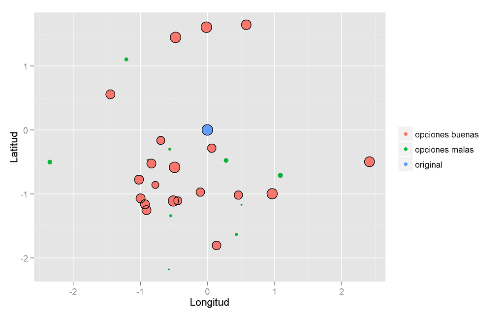

## Integrando todo

- Definir un radio de cercanía razonable
  - Ignorar hoteles caros (precio de largo plazo)
  - Acumular una cantidad de similitud
- Recomendar dentro de la geocerca
  - Ignorar hoteles caros (precio en fecha de la búsqueda)
  - Ordenar por mayor similitud

## Integrando todo

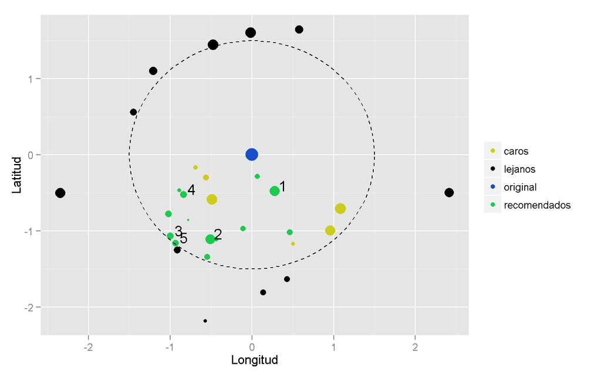

## Mucha plática y poca acción…

## Mucha plática y poca acción…

Demo

## Notas sobre la implementación

- **Respaldo:**
  - Destino + Estrellas + Sort Order (en fecha buscada)
  - Para hoteles que no han entrado al sistema *aún*
  - Por si hay algún error
- Aún no está el precio dinámico
  - Se filtra desde el principio con precio de largo plazo
- La base de servicios está sucia
  - Diferente formato para hoteles EAN
  - Se está trabajando en la limpieza

## Qué **sí** hace

- **Recomienda** hoteles similares
- Toma en cuenta el **precio**
- Toma en cuenta la **cercanía**
- Promueve que el cliente **explore la página**
  - Recomendaciones no transitivas

## Qué **no** hace (y no queremos que haga)

- **No** encuentra sets competitivos
  - Lo importante es cerrar ventas
- **No** da mayor peso a promociones
  - Enfoque distinto

## Qué **podría** hacer

- **Incorporar** más hoteles (EAN)
- **Ser más preciso** si se aumenta el detalle de servicios

(Más) preguntas

¡Gracias!